# GoBike data exploration

## Preliminary Wrangling

> This data set includes information about individual rides made in a bike-sharing system covering the greater San Francisco Bay area

```python
# import all packages and set plots to be embedded inline
import numpy as np
import pandas as pd
import matplotlib.pyplot as plt
import seaborn as sb

%matplotlib inline
```

> Load in your dataset and describe its properties through the questions below. Try and motivate your exploration goals through this section.

```python
df = pd.read_csv('gobike.csv')
df.head()
```

|  | duration_sec | start_time | end_time | start_station_id | start_station_name | start_station_latitude | start_station_longitude | end_station_id | end_station_name | end_station_latitude | end_station_longitude | bike_id | user_type | member_birth_year | member_gender | bike_share_for_all_trip |
| --- | --- | --- | --- | --- | --- | --- | --- | --- | --- | --- | --- | --- | --- | --- | --- | --- |
| 0 | 52185 | 2019-02-28 17:32:10.1450 | 2019-03-01 08:01:55.9750 | 21.0 | Montgomery St BART Station (Market St at 2nd St) | 37.789625 | -122.400811 | 13.0 | Commercial St at Montgomery St | 37.794231 | -122.402923 | 4902 | Customer | 1984.0 | Male | No |
| 1 | 42521 | 2019-02-28 18:53:21.7890 | 2019-03-01 06:42:03.0560 | 23.0 | The Embarcadero at Steuart St | 37.791464 | -122.391034 | 81.0 | Berry St at 4th St | 37.775880 | -122.393170 | 2535 | Customer | NaN | NaN | No |
| 2 | 61854 | 2019-02-28 12:13:13.2180 | 2019-03-01 05:24:08.1460 | 86.0 | Market St at Dolores St | 37.769305 | -122.426826 | 3.0 | Powell St BART Station (Market St at 4th St) | 37.786375 | -122.404904 | 5905 | Customer | 1972.0 | Male | No |
| 3 | 36490 | 2019-02-28 17:54:26.0100 | 2019-03-01 04:02:36.8420 | 375.0 | Grove St at Masonic Ave | 37.774836 | -122.446546 | 70.0 | Central Ave at Fell St | 37.773311 | -122.444293 | 6638 | Subscriber | 1989.0 | Other | No |
| 4 | 1585 | 2019-02-28 23:54:18.5490 | 2019-03-01 00:20:44.0740 | 7.0 | Frank H Ogawa Plaza | 37.804562 | -122.271738 | 222.0 | 10th Ave at E 15th St | 37.792714 | -122.248780 | 4898 | Subscriber | 1974.0 | Male | Yes |

## discovering our dataset 3..2..1

```python
df.info()
```

```
<class 'pandas.core.frame.DataFrame'>
RangeIndex: 183412 entries, 0 to 183411
Data columns (total 16 columns):
 #   Column                   Non-Null Count   Dtype
---  ------                   --------------   -----
 0   duration_sec             183412 non-null  int64
 1   start_time               183412 non-null  object
 2   end_time                 183412 non-null  object
 3   start_station_id         183215 non-null  float64
 4   start_station_name       183215 non-null  object
 5   start_station_latitude   183412 non-null  float64
 6   start_station_longitude  183412 non-null  float64
 7   end_station_id           183215 non-null  float64
 8   end_station_name         183215 non-null  object
 9   end_station_latitude     183412 non-null  float64
 10  end_station_longitude    183412 non-null  float64
 11  bike_id                  183412 non-null  int64
 12  user_type                183412 non-null  object
 13  member_birth_year        175147 non-null  float64
 14  member_gender            175147 non-null  object
 15  bike_share_for_all_trip  183412 non-null  object
dtypes: float64(7), int64(2), object(7)
memory usage: 22.4+ MB
```

```python
df.describe()
```

|  | duration_sec | start_station_id | start_station_latitude | start_station_longitude | end_station_id | end_station_latitude | end_station_longitude | bike_id | member_birth_year |
| --- | --- | --- | --- | --- | --- | --- | --- | --- | --- |
| count | 183412.000000 | 183215.000000 | 183412.000000 | 183412.000000 | 183215.000000 | 183412.000000 | 183412.000000 | 183412.000000 | 175147.000000 |
| mean | 726.078435 | 138.590427 | 37.771223 | -122.352664 | 136.249123 | 37.771427 | -122.352250 | 4472.906375 | 1984.806437 |
| std | 1794.389780 | 111.778864 | 0.099581 | 0.117097 | 111.515131 | 0.099490 | 0.116673 | 1664.383394 | 10.116689 |
| min | 61.000000 | 3.000000 | 37.317298 | -122.453704 | 3.000000 | 37.317298 | -122.453704 | 11.000000 | 1878.000000 |
| 25% | 325.000000 | 47.000000 | 37.770083 | -122.412408 | 44.000000 | 37.770407 | -122.411726 | 3777.000000 | 1980.000000 |
| 50% | 514.000000 | 104.000000 | 37.780760 | -122.398285 | 100.000000 | 37.781010 | -122.398279 | 4958.000000 | 1987.000000 |
| 75% | 796.000000 | 239.000000 | 37.797280 | -122.286533 | 235.000000 | 37.797320 | -122.288045 | 5502.000000 | 1992.000000 |
| max | 85444.000000 | 398.000000 | 37.880222 | -121.874119 | 398.000000 | 37.880222 | -121.874119 | 6645.000000 | 2001.000000 |

```python
#null values count in each column
df.isna().sum()
```

```
duration_sec                  0
start_time                    0
end_time                      0
start_station_id            197
start_station_name          197
start_station_latitude        0
start_station_longitude       0
end_station_id              197
end_station_name            197
end_station_latitude          0
end_station_longitude         0
bike_id                       0
user_type                     0
member_birth_year          8265
member_gender              8265
bike_share_for_all_trip       0
dtype: int64
```

```python
#no of bikes in dataset
df.bike_id.nunique()
```

```
4646
```

```python
#no. of trips per bike
df.bike_id.value_counts()
```

```
4794    191
4814    176
5014    174
4422    174
5175    173
       ...
5647      1
3655      1
1194      1
3114      1
5891      1
Name: bike_id, Length: 4646, dtype: int64
```

```python
#no. of start_station_id , end_station_id
df.start_station_id.nunique(), df.end_station_id.nunique()
```

```
(329, 329)
```

```python
#no of trips started from each station:
df.start_station_name.value_counts()
```

```
Market St at 10th St                                         3904
San Francisco Caltrain Station 2  (Townsend St at 4th St)    3544
Berry St at 4th St                                           3052
Montgomery St BART Station (Market St at 2nd St)             2895
Powell St BART Station (Market St at 4th St)                 2760
                                                             ...
Willow St at Vine St                                            9
Parker Ave at McAllister St                                     7
21st Ave at International Blvd                                  4
Palm St at Willow St                                            4
16th St Depot                                                   2
Name: start_station_name, Length: 329, dtype: int64
```

```python
#no of trips ended from each station:
df.end_station_id.value_counts()
```

```
67.0     4857
58.0     3973
21.0     3647
15.0     3368
3.0      2997
         ...
51.0        9
300.0       7
224.0       6
344.0       6
301.0       5
Name: end_station_id, Length: 329, dtype: int64
```

```python
#convert date from string to datetime
df['start_time'] = pd.to_datetime(df['start_time'])
df['end_time'] = pd.to_datetime(df['end_time'])
```

```python
#range of dates for start_time
df.start_time.min(), df.start_time.max()
```

```
(Timestamp('2019-02-01 00:00:20.636000'),
 Timestamp('2019-02-28 23:59:18.548000'))
```

```python
#range of dates for end_time
df.end_time.min(), df.end_time.max()
```

```
(Timestamp('2019-02-01 00:04:52.058000'),
 Timestamp('2019-03-01 08:01:55.975000'))
```

### What is the structure of your dataset?

> There are 183412 trips in our dataset, we have 4646 unique bikes and the data is collected for Feb2019, we have 329 unique stations and we have 197 trip with no station name or id (maybe the user did not leave it in a station or the bike may had been broken or stolen!)

### What is/are the main feature(s) of interest in your dataset?

> I am interesting to know the stations with no bike at all in certain times of a day because it means easy profit we miss.

### What features in the dataset do you think will help support your investigation into your feature(s) of interest?

> our main interest is the time of the day so I will use **start_time, end_time, start_id, end_id, bike_id, user_type, member_birth_year , member_gender and bike_share_for_all_trip**

> I want to investigate more those 197 trip with no stattion id :

```python
df_noid = df[df['start_station_id'].isna()]
df_noid
```

|  | duration_sec | start_time | end_time | start_station_id | start_station_name | start_station_latitude | start_station_longitude | end_station_id | end_station_name | end_station_latitude | end_station_longitude | bike_id | user_type | member_birth_year | member_gender | bike_share_for_all_trip |
| --- | --- | --- | --- | --- | --- | --- | --- | --- | --- | --- | --- | --- | --- | --- | --- | --- |
| 475 | 1709 | 2019-02-28 20:55:53.932 | 2019-02-28 21:24:23.738 | NaN | NaN | 37.40 | -121.94 | NaN | NaN | 37.40 | -121.93 | 4211 | Customer | 1991.0 | Female | No |
| 1733 | 1272 | 2019-02-28 18:32:34.273 | 2019-02-28 18:53:46.727 | NaN | NaN | 37.40 | -121.94 | NaN | NaN | 37.41 | -121.96 | 4174 | Subscriber | 1980.0 | Male | No |
| 3625 | 142 | 2019-02-28 17:10:46.529 | 2019-02-28 17:13:09.431 | NaN | NaN | 37.41 | -121.95 | NaN | NaN | 37.41 | -121.96 | 4283 | Subscriber | 1988.0 | Male | No |
| 4070 | 585 | 2019-02-28 16:28:45.934 | 2019-02-28 16:38:31.332 | NaN | NaN | 37.39 | -121.93 | NaN | NaN | 37.40 | -121.92 | 4089 | Subscriber | 1984.0 | Male | Yes |
| 5654 | 509 | 2019-02-28 12:30:17.131 | 2019-02-28 12:38:46.329 | NaN | NaN | 37.40 | -121.92 | NaN | NaN | 37.39 | -121.93 | 4089 | Subscriber | 1984.0 | Male | Yes |
| ... | ... | ... | ... | ... | ... | ... | ... | ... | ... | ... | ... | ... | ... | ... | ... | ... |
| 176154 | 1447 | 2019-02-02 12:03:04.544 | 2019-02-02 12:27:12.267 | NaN | NaN | 37.40 | -121.93 | NaN | NaN | 37.40 | -121.93 | 4249 | Customer | 1984.0 | Male | No |
| 179730 | 309 | 2019-02-01 12:59:45.969 | 2019-02-01 13:04:55.426 | NaN | NaN | 37.40 | -121.94 | NaN | NaN | 37.40 | -121.93 | 4249 | Customer | 1987.0 | Female | No |
| 179970 | 659 | 2019-02-01 12:17:37.675 | 2019-02-01 12:28:37.014 | NaN | NaN | 37.41 | -121.96 | NaN | NaN | 37.41 | -121.94 | 4092 | Subscriber | 1999.0 | Female | No |
| 180106 | 2013 | 2019-02-01 11:33:55.147 | 2019-02-01 12:07:28.940 | NaN | NaN | 37.40 | -121.94 | NaN | NaN | 37.40 | -121.94 | 4251 | Customer | 1990.0 | Female | No |
| 181201 | 312 | 2019-02-01 09:26:34.803 | 2019-02-01 09:31:46.921 | NaN | NaN | 37.40 | -121.93 | NaN | NaN | 37.40 | -121.93 | 4208 | Subscriber | 1987.0 | Male | No |

197 rows × 16 columns

```python
df_noid.start_time.min()
```

```
Timestamp('2019-02-01 09:26:34.803000')
```

```python
df_noid.start_time.max()
```

```
Timestamp('2019-02-28 20:55:53.932000')
```

```python
df_noid.describe()
```

|  | duration_sec | start_station_id | start_station_latitude | start_station_longitude | end_station_id | end_station_latitude | end_station_longitude | bike_id | member_birth_year |
| --- | --- | --- | --- | --- | --- | --- | --- | --- | --- |
| count | 197.000000 | 0.0 | 197.000000 | 197.000000 | 0.0 | 197.000000 | 197.000000 | 197.000000 | 195.000000 |
| mean | 890.152284 | NaN | 37.406599 | -121.943401 | NaN | 37.406091 | -121.943096 | 4182.350254 | 1987.769231 |
| std | 947.517539 | NaN | 0.007634 | 0.012376 | NaN | 0.008047 | 0.012859 | 63.783228 | 7.534325 |
| min | 66.000000 | NaN | 37.380000 | -121.980000 | NaN | 37.380000 | -121.980000 | 3975.000000 | 1960.000000 |
| 25% | 341.000000 | NaN | 37.400000 | -121.950000 | NaN | 37.400000 | -121.950000 | 4141.000000 | 1984.000000 |
| 50% | 660.000000 | NaN | 37.410000 | -121.940000 | NaN | 37.410000 | -121.940000 | 4174.000000 | 1988.000000 |
| 75% | 999.000000 | NaN | 37.410000 | -121.930000 | NaN | 37.410000 | -121.930000 | 4239.000000 | 1992.000000 |
| max | 8209.000000 | NaN | 37.420000 | -121.920000 | NaN | 37.430000 | -121.920000 | 4283.000000 | 2000.000000 |

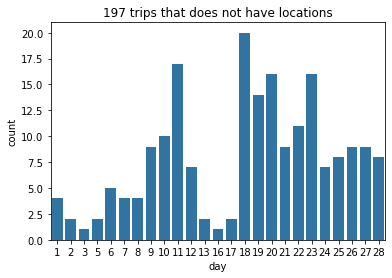

```python
base_color = sb.color_palette()[0]
sb.countplot(df_noid['start_time'].dt.day, color=base_color)
plt.title('197 trips that does not have locations')
plt.xlabel('day');
```

> by investigating those 197 trip we found that all of those trips started or ended in San Jose,Ca (I investigated the max and min longitude and latitude in google maps).

> so I think there is someting missed in this area and to be safe we will drop those data

```python
df.dropna(subset=['start_station_id'], inplace=True)
df.isna().sum()
```

```
duration_sec                  0
start_time                    0
end_time                      0
start_station_id              0
start_station_name            0
start_station_latitude        0
start_station_longitude       0
end_station_id                0
end_station_name              0
end_station_latitude          0
end_station_longitude         0
bike_id                       0
user_type                     0
member_birth_year          8263
member_gender              8263
bike_share_for_all_trip       0
dtype: int64
```

## Univariate Exploration

I am going to investigate the start_time variable and see what times has the most trips:

### How many trips in every weekday?

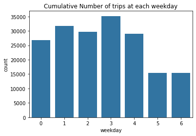

```python
sb.countplot(df.start_time.dt.weekday, color=base_color)
plt.title('Cumulative Number of trips at each weekday')
plt.xlabel('weekday');
```

Seems that most users use the bikes at workdays(Mondays to Fridays) and the traffic is decreasing up to 50% at the weekend. let's see what happens during the day.

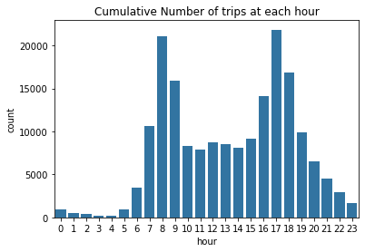

```python
sb.countplot(df.start_time.dt.hour, color = base_color)
plt.title('Cumulative Number of trips at each hour')
plt.xlabel('hour');
```

As expected, most of the trips happens between (7:00 am-10:00am) when people are going to their work and between(16:00pm -19:00pm) when people returning from their work. We could see bimodility in the distribution above. Let's see what will happens if we just include the workdays only and weekends only.

Now let's see how the duration of the trips look like:

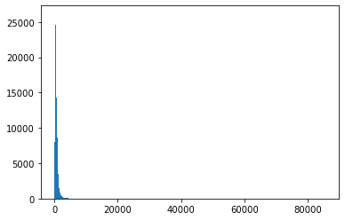

```python
binwidth = 100
bins = np.arange(60,df.duration_sec.max()+binwidth, binwidth)
plt.hist(df.duration_sec, color=base_color, bins=bins);
```

As we could see the distribution is extremely skewed to right means that most trips has short durations (75% of trips has a duration less than 1000 sec = (16min and 40sec) as we could see from describe method). That gives an indicator that most users use the bike for one go. let's see what happens when we transfer to log scale:

```python
np.log10(df.duration_sec).describe()
```

```
count    183215.000000
mean          2.712516
std           0.309322
min           1.785330
25%           2.511883
50%           2.710963
75%           2.900913
max           4.931682
Name: duration_sec, dtype: float64
```

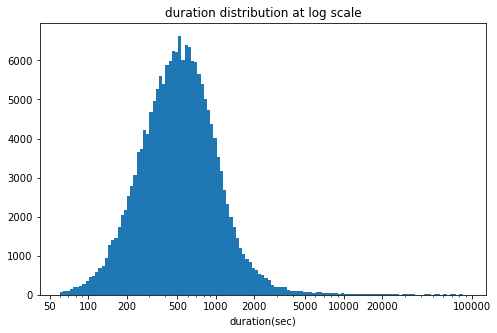

```python
log_binsize = 0.025
bins = 10 ** np.arange(1.78, np.log10(df.duration_sec.max())+log_binsize, log_binsize)

plt.figure(figsize=[8, 5])
plt.hist(data = df, x = 'duration_sec', bins = bins)
plt.xscale('log')
plt.xticks([50,100,200,500, 1e3, 2e3, 5e3, 1e4, 2e4,1e5],
           [50,100,200,500, '1000', '2000', '5000', '10000', '20000','100000'])
plt.xlabel('duration(sec)')
plt.title('duration distribution at log scale');
```

now we could see that our transformed duration with log scale has nearly normal distribution with right long tail. these trips with high duration needs more exploration to see its charchteristics.

### let's get some insights about the bikes, when they first appear at our data and when they last appear:

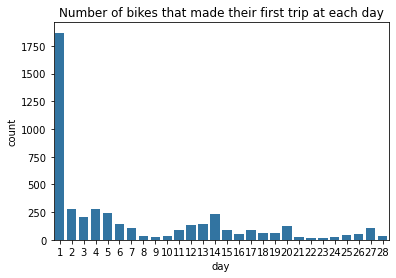

```python
first_appear = df.groupby('bike_id')['start_time'].min()
sb.countplot(first_appear.dt.day, color=base_color)
plt.title('Number of bikes that made their first trip at each day')
plt.xlabel('day');
```

I could see there is a slight increase in bikes starting from 11-Feb

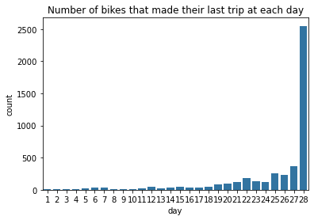

```python
last_appear = df.groupby('bike_id')['start_time'].max()
sb.countplot(last_appear.dt.day, color=base_color)
plt.xlabel('day')
plt.title('Number of bikes that made their last trip at each day')
```

As we could see from the distribution above there are number of bikes stop working everyday maybe because it is broken, out of service, changing its id or stolen! At the end day of the month which was a workday(Thu), there are about 2500 bikes doing trips from 4646 bikes in our dataset (about 54%) .. we need to improve this metric if we need to gain more profits.

## Bivariate Exploration

### What are the number of trips during the day for workdays and weekends?

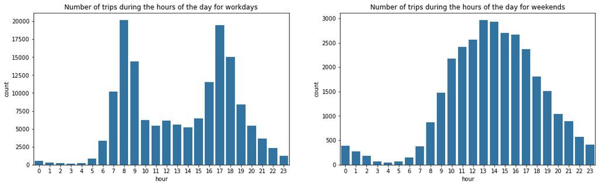

```python
# Extract weekday and hour
df['weekday'] = df.start_time.dt.weekday
df['hour'] = df.start_time.dt.hour
#divide df to workdays and weekend:
df_workday = df.query('weekday!=5 & weekday!=6')
df_weekend = df.query('weekday==5 | weekday==6')
#ploting
plt.figure(figsize=(18,5))

plt.subplot(1,2,1)
sb.countplot(df_workday.start_time.dt.hour, color=base_color)
plt.title('Number of trips during the hours of the day for workdays')
plt.xlabel('hour')

plt.subplot(1,2,2)
sb.countplot(df_weekend.start_time.dt.hour, color=base_color)
plt.title('Number of trips during the hours of the day for weekends');
plt.xlabel('hour');
```

I want to investigate the distribution of trips per stations. since we have 329 station, it will be very hard to investigate each station so I will choose the top ones.

```python
#convert to string type:
df['start_station_id'] = df['start_station_id'].astype(int).astype(str)
df['end_station_id'] = df['end_station_id'].astype(int).astype(str)

# get the list of top stations (has more than 1000 trip)
station_start_ids = df.start_station_id.value_counts().reset_index(name='count').query('count > 1000')['index']
station_end_ids = df.end_station_id.value_counts().reset_index(name='count').query('count > 1000')['index']
station_ids = list(set(list(station_start_ids) + list(station_end_ids)))
len(station_ids) , station_ids
```

```
(47,
 ['245',
  '343',
  '223',
  '130',
  '5',
  '80',
  '134',
  '74',
  '3',
  '182',
  '256',
  '67',
  '81',
  '176',
  '16',
  '114',
  '24',
  '22',
  '59',
  '90',
  '371',
  '93',
  '126',
  '30',
  '44',
  '20',
  '43',
  '50',
  '239',
  '66',
  '17',
  '321',
  '61',
  '350',
  '27',
  '60',
  '19',
  '15',
  '6',
  '36',
  '21',
  '89',
  '243',
  '23',
  '324',
  '58',
  '104'])
```

We get the ids of top stations in our dataset that have more than 1000 trip in or out , they are 47 station. we are going to see the distribution of trips in this station per day

```python
#get the trips of top stations
df_top_start = df[df['start_station_id'].isin(station_ids)]
df_top_start.head(5)
```

|  | duration_sec | start_time | end_time | start_station_id | start_station_name | start_station_latitude | start_station_longitude | end_station_id | end_station_name | end_station_latitude | end_station_longitude | bike_id | user_type | member_birth_year | member_gender | bike_share_for_all_trip | weekday | hour |
| --- | --- | --- | --- | --- | --- | --- | --- | --- | --- | --- | --- | --- | --- | --- | --- | --- | --- | --- |
| 0 | 52185 | 2019-02-28 17:32:10.145 | 2019-03-01 08:01:55.975 | 21 | Montgomery St BART Station (Market St at 2nd St) | 37.789625 | -122.400811 | 13 | Commercial St at Montgomery St | 37.794231 | -122.402923 | 4902 | Customer | 1984.0 | Male | No | 3 | 17 |
| 1 | 42521 | 2019-02-28 18:53:21.789 | 2019-03-01 06:42:03.056 | 23 | The Embarcadero at Steuart St | 37.791464 | -122.391034 | 81 | Berry St at 4th St | 37.775880 | -122.393170 | 2535 | Customer | NaN | NaN | No | 3 | 18 |
| 5 | 1793 | 2019-02-28 23:49:58.632 | 2019-03-01 00:19:51.760 | 93 | 4th St at Mission Bay Blvd S | 37.770407 | -122.391198 | 323 | Broadway at Kearny | 37.798014 | -122.405950 | 5200 | Subscriber | 1959.0 | Male | No | 3 | 23 |
| 9 | 1049 | 2019-02-28 23:49:47.699 | 2019-03-01 00:07:17.025 | 19 | Post St at Kearny St | 37.788975 | -122.403452 | 121 | Mission Playground | 37.759210 | -122.421339 | 6488 | Subscriber | 1992.0 | Male | No | 3 | 23 |
| 11 | 506 | 2019-02-28 23:56:55.540 | 2019-03-01 00:05:21.733 | 44 | Civic Center/UN Plaza BART Station (Market St ... | 37.781074 | -122.411738 | 343 | Bryant St at 2nd St | 37.783172 | -122.393572 | 5848 | Subscriber | 1993.0 | Male | No | 3 | 23 |

```python
df_top_start.start_station_id.nunique()
```

```
47
```

### how many trips started during each hour for each station during the month?

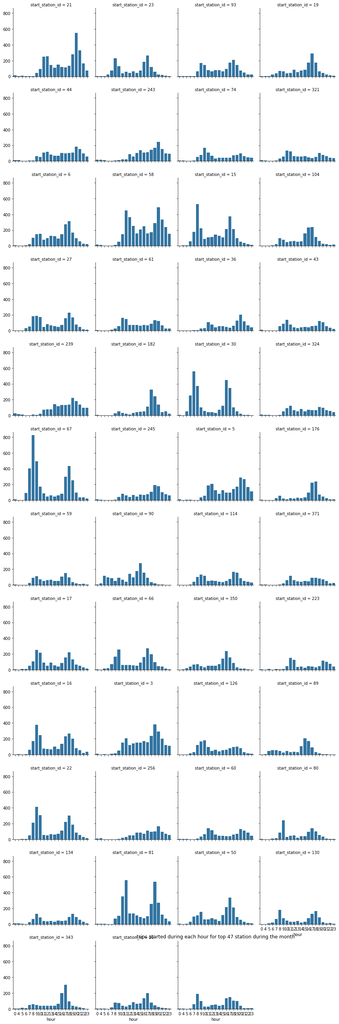

```python
#plotting :
g = sb.FacetGrid(data=df_top_start, col='start_station_id', col_wrap=4)
g.map(sb.countplot, 'hour', color=base_color);
plt.title('trips started during each hour for top 47 station during the month');
```

we could see that most of the top stations has biomodal distribution and some have more trips at leaving work hours like stations (19, 104, 343, ..).

let's see the distibution for the trips ended at these stations:

```python
#get the trips of top stations
df_top_end = df[df['end_station_id'].isin(station_ids)]
df_top_end
```

|  | duration_sec | start_time | end_time | start_station_id | start_station_name | start_station_latitude | start_station_longitude | end_station_id | end_station_name | end_station_latitude | end_station_longitude | bike_id | user_type | member_birth_year | member_gender | bike_share_for_all_trip | weekday | hour |
| --- | --- | --- | --- | --- | --- | --- | --- | --- | --- | --- | --- | --- | --- | --- | --- | --- | --- | --- |
| 1 | 42521 | 2019-02-28 18:53:21.789 | 2019-03-01 06:42:03.056 | 23 | The Embarcadero at Steuart St | 37.791464 | -122.391034 | 81 | Berry St at 4th St | 37.775880 | -122.393170 | 2535 | Customer | NaN | NaN | No | 3 | 18 |
| 2 | 61854 | 2019-02-28 12:13:13.218 | 2019-03-01 05:24:08.146 | 86 | Market St at Dolores St | 37.769305 | -122.426826 | 3 | Powell St BART Station (Market St at 4th St) | 37.786375 | -122.404904 | 5905 | Customer | 1972.0 | Male | No | 3 | 12 |
| 10 | 458 | 2019-02-28 23:57:57.211 | 2019-03-01 00:05:35.435 | 370 | Jones St at Post St | 37.787327 | -122.413278 | 43 | San Francisco Public Library (Grove St at Hyde... | 37.778768 | -122.415929 | 5318 | Subscriber | 1996.0 | Female | Yes | 3 | 23 |
| 11 | 506 | 2019-02-28 23:56:55.540 | 2019-03-01 00:05:21.733 | 44 | Civic Center/UN Plaza BART Station (Market St ... | 37.781074 | -122.411738 | 343 | Bryant St at 2nd St | 37.783172 | -122.393572 | 5848 | Subscriber | 1993.0 | Male | No | 3 | 23 |
| 15 | 208 | 2019-02-28 23:59:18.548 | 2019-03-01 00:02:47.228 | 349 | Howard St at Mary St | 37.781010 | -122.405666 | 60 | 8th St at Ringold St | 37.774520 | -122.409449 | 6361 | Subscriber | 1993.0 | Male | Yes | 3 | 23 |
| ... | ... | ... | ... | ... | ... | ... | ... | ... | ... | ... | ... | ... | ... | ... | ... | ... | ... | ... |
| 183399 | 958 | 2019-02-01 00:12:24.247 | 2019-02-01 00:28:22.738 | 67 | San Francisco Caltrain Station 2 (Townsend St... | 37.776639 | -122.395526 | 58 | Market St at 10th St | 37.776619 | -122.417385 | 3392 | Subscriber | 1993.0 | Male | No | 4 | 0 |
| 183400 | 250 | 2019-02-01 00:23:52.611 | 2019-02-01 00:28:02.679 | 356 | Valencia St at Clinton Park | 37.769188 | -122.422285 | 58 | Market St at 10th St | 37.776619 | -122.417385 | 4962 | Subscriber | 1984.0 | Male | No | 4 | 0 |
| 183405 | 111 | 2019-02-01 00:14:49.874 | 2019-02-01 00:16:41.301 | 324 | Union Square (Powell St at Post St) | 37.788300 | -122.408531 | 19 | Post St at Kearny St | 37.788975 | -122.403452 | 4832 | Subscriber | 1984.0 | Male | No | 4 | 0 |
| 183407 | 480 | 2019-02-01 00:04:49.724 | 2019-02-01 00:12:50.034 | 27 | Beale St at Harrison St | 37.788059 | -122.391865 | 324 | Union Square (Powell St at Post St) | 37.788300 | -122.408531 | 4832 | Subscriber | 1996.0 | Male | No | 4 | 0 |
| 183408 | 313 | 2019-02-01 00:05:34.744 | 2019-02-01 00:10:48.502 | 21 | Montgomery St BART Station (Market St at 2nd St) | 37.789625 | -122.400811 | 66 | 3rd St at Townsend St | 37.778742 | -122.392741 | 4960 | Subscriber | 1984.0 | Male | No | 4 | 0 |

79982 rows × 18 columns

```python
df_top_end.end_station_id.nunique()
```

```
47
```

### how many trips ended during each hour for each station during the month?

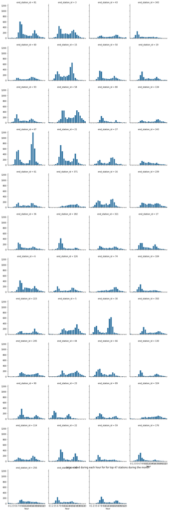

```python
#plotting :
g = sb.FacetGrid(data=df_top_end, col='end_station_id', col_wrap=4)
g.map(sb.countplot, 'hour', color=base_color)
plt.title('trips ended during each hour for for top 47 stations during the month');
```

by comparing the staring and ending trips in each station during the day we could see the patterns that happen at each day. I may add a new dimenion in multvariate exploration to see what happens in each station in workdays and weekends(I may use line charts with hue).

## Multivariate exploration:

### how many trips started during each hour for top stations during the month for workdays and weekends?

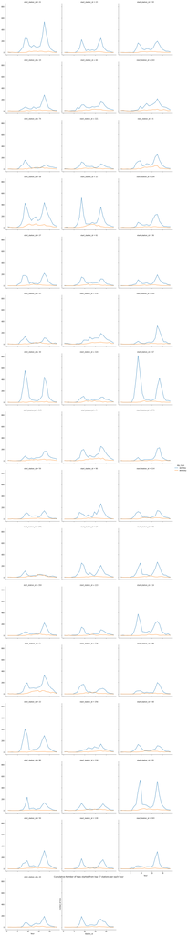

```python
df_top_start['day_type'] = np.where(df_top_start['weekday'] > 4 , 'weekday', 'workday')

def freq_poly(x, bins = 10, **kwargs):
    """ Custom frequency polygon / line plot code. """
    # set bin edges if none or int specified
    if type(bins) == int:
        bins = np.linspace(x.min(), x.max(), bins+1)
    bin_centers = (bin_edges[1:] + bin_edges[:-1]) / 2

    # compute counts
    data_bins = pd.cut(x, bins, right = False,
                       include_lowest = True)
    counts = x.groupby(data_bins).count()

    # create plot
    plt.errorbar(x = bin_centers, y = counts, **kwargs)

bin_edges = np.arange(0, 24+1, 1)
g = sb.FacetGrid(data = df_top_start, hue = 'day_type',col='start_station_id',col_wrap=3, size = 5)
g.map(freq_poly, "hour", bins = bin_edges)
g.add_legend()
plt.xlabel('Station_id')
plt.ylabel('number of trips')
plt.title('Cumulative Number of trips started from top 47 stations per each hour ')
```

### how many trips ended during each hour for top stations during the month for workdays and weekends?

```python
df_top_end.end_station_id.nunique()
```

```
47
```

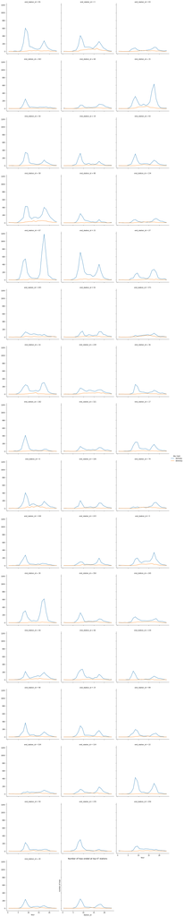

```python
df_top_end['day_type'] = np.where(df_top_end['weekday'] > 4 , 'weekday', 'workday')



def freq_poly(x, bins = 10, **kwargs):
    """ Custom frequency polygon / line plot code. """
    # set bin edges if none or int specified
    if type(bins) == int:
        bins = np.linspace(x.min(), x.max(), bins+1)
    bin_centers = (bin_edges[1:] + bin_edges[:-1]) / 2

    # compute counts
    data_bins = pd.cut(x, bins, right = False,
                       include_lowest = True)
    counts = x.groupby(data_bins).count()

    # create plot
    plt.errorbar(x = bin_centers, y = counts, **kwargs)

bin_edges = np.arange(0, 24+1, 1)
g = sb.FacetGrid(data = df_top_end, hue = 'day_type',col='end_station_id',col_wrap=3, size = 5)
g.map(freq_poly, "hour", bins = bin_edges)
g.add_legend()
plt.xlabel('Station_id')
plt.ylabel('number of trips')
plt.title('Number of trips ended at top 47 stations per each hour')
```

Now I want to see if the company make daily transfer from station to station. So if the start station of a certain trip should match the end station of the last trip of the same bike. If does not then the company had transferred it.

```python
#order the dataset by bike_id then by start_time
df_ordered = df.sort_values(by=['bike_id', 'start_time']).reset_index()
df_ordered.loc[470:480,]
```

|  | index | duration_sec | start_time | end_time | start_station_id | start_station_name | start_station_latitude | start_station_longitude | end_station_id | end_station_name | end_station_latitude | end_station_longitude | bike_id | user_type | member_birth_year | member_gender | bike_share_for_all_trip | weekday | hour |
| --- | --- | --- | --- | --- | --- | --- | --- | --- | --- | --- | --- | --- | --- | --- | --- | --- | --- | --- | --- |
| 470 | 147866 | 360 | 2019-02-07 06:59:42.277 | 2019-02-07 07:05:42.555 | 189 | Genoa St at 55th St | 37.839649 | -122.271756 | 176 | MacArthur BART Station | 37.828410 | -122.266315 | 52 | Subscriber | 1990.0 | Male | No | 3 | 6 |
| 471 | 142348 | 401 | 2019-02-07 17:13:24.529 | 2019-02-07 17:20:06.230 | 243 | Bancroft Way at College Ave | 37.869360 | -122.254337 | 268 | Ellsworth St at Russell St | 37.857490 | -122.261578 | 52 | Subscriber | 1989.0 | Male | No | 3 | 17 |
| 472 | 134558 | 346 | 2019-02-08 17:16:19.082 | 2019-02-08 17:22:06.029 | 268 | Ellsworth St at Russell St | 37.857490 | -122.261578 | 241 | Ashby BART Station | 37.852477 | -122.270213 | 52 | Subscriber | 1981.0 | Male | No | 4 | 17 |
| 473 | 133468 | 673 | 2019-02-08 18:55:32.101 | 2019-02-08 19:06:45.198 | 241 | Ashby BART Station | 37.852477 | -122.270213 | 246 | Berkeley Civic Center | 37.869060 | -122.270556 | 52 | Subscriber | 1991.0 | Male | No | 4 | 18 |
| 474 | 128265 | 1487 | 2019-02-10 13:24:54.573 | 2019-02-10 13:49:42.248 | 246 | Berkeley Civic Center | 37.869060 | -122.270556 | 174 | Shattuck Ave at 51st St | 37.836801 | -122.264004 | 52 | Customer | 1993.0 | Female | No | 6 | 13 |
| 475 | 95026 | 1379 | 2019-02-15 14:59:57.240 | 2019-02-15 15:22:56.486 | 174 | Shattuck Ave at 51st St | 37.836801 | -122.264004 | 205 | Miles Ave at Cavour St | 37.838800 | -122.258732 | 52 | Subscriber | 1988.0 | Male | No | 4 | 14 |
| 476 | 93226 | 267 | 2019-02-15 17:56:02.993 | 2019-02-15 18:00:30.247 | 256 | Hearst Ave at Euclid Ave | 37.875112 | -122.260553 | 245 | Downtown Berkeley BART | 37.870139 | -122.268422 | 52 | Subscriber | 1953.0 | Male | No | 4 | 17 |
| 477 | 92839 | 1051 | 2019-02-15 18:09:04.442 | 2019-02-15 18:26:35.459 | 245 | Downtown Berkeley BART | 37.870139 | -122.268422 | 207 | Broadway at Coronado Ave | 37.835788 | -122.251621 | 52 | Subscriber | 1974.0 | Male | No | 4 | 18 |
| 478 | 82534 | 1111 | 2019-02-18 09:41:54.483 | 2019-02-18 10:00:25.862 | 207 | Broadway at Coronado Ave | 37.835788 | -122.251621 | 245 | Downtown Berkeley BART | 37.870139 | -122.268422 | 52 | Subscriber | 1974.0 | Male | No | 0 | 9 |
| 479 | 78695 | 571 | 2019-02-18 18:49:51.901 | 2019-02-18 18:59:23.794 | 245 | Downtown Berkeley BART | 37.870139 | -122.268422 | 263 | Channing Way at San Pablo Ave | 37.862827 | -122.290230 | 52 | Subscriber | 1995.0 | Male | No | 0 | 18 |
| 480 | 11115 | 773 | 2019-02-27 18:58:37.065 | 2019-02-27 19:11:30.645 | 256 | Hearst Ave at Euclid Ave | 37.875112 | -122.260553 | 256 | Hearst Ave at Euclid Ave | 37.875112 | -122.260553 | 52 | Subscriber | 1994.0 | Female | No | 2 | 18 |

```python
df_ordered.loc[474,'start_station_id'] == df_ordered.loc[473,'end_station_id']
```

```
True
```

```python
for i in range(1, len(df_ordered)):
    try:
        if df_ordered.loc[i,'bike_id'] == df_ordered.loc[i-1,'bike_id']:
            if df_ordered.loc[i,'start_station_id'] == df_ordered.loc[i-1,'end_station_id'] :
                df_ordered.loc[i,'transfered'] = False
            else:
                df_ordered.loc[i,'transfered'] = True
        else:
            df_ordered.loc[i,'transfered'] = 'new'
    except:
        print(i)
```

```
24748
26904
```

```python
print('no. of unique bikes = {}'.format(df_ordered.bike_id.nunique()))
#change the first row value from NaN to 'new'
df_ordered.transfered.value_counts()
```

[output not shown]

I will save the last dataset because it takes a lot of time. If you have a vectorization solution for that loop I will be grateful!

```python
df_ordered.to_csv('gobike_ordered.csv')
```

```python
df_ordered
```

[output not shown]

183215 rows × 20 columns

```python
df_ordered = pd.read_csv('gobike_ordered.csv')
df_ordered.drop(columns=['Unnamed: 0','index'], inplace=True)
#some type convertions
df_ordered['start_time'] = pd.to_datetime(df_ordered['start_time'])
df_ordered['end_time'] = pd.to_datetime(df_ordered['end_time'])
df_ordered['start_station_id'] = df_ordered['start_station_id'].astype(int).astype(str)
df_ordered['end_station_id'] = df_ordered['end_station_id'].astype(int).astype(str)
df_ordered['bike_id'] = df_ordered['bike_id'].astype(int).astype(str)
```

```python
df_ordered.head()
```

|  | duration_sec | start_time | end_time | start_station_id | start_station_name | start_station_latitude | start_station_longitude | end_station_id | end_station_name | end_station_latitude | end_station_longitude | bike_id | user_type | member_birth_year | member_gender | bike_share_for_all_trip | weekday | hour | transfered |
| --- | --- | --- | --- | --- | --- | --- | --- | --- | --- | --- | --- | --- | --- | --- | --- | --- | --- | --- | --- |
| 0 | 1038 | 2019-02-01 07:26:39.895 | 2019-02-01 07:43:58.101 | 345 | Hubbell St at 16th St | 37.766483 | -122.398279 | 25 | Howard St at 2nd St | 37.787522 | -122.397405 | 11 | Customer | 1978.0 | Male | No | 4 | 7 | NaN |
| 1 | 153 | 2019-02-01 18:55:10.826 | 2019-02-01 18:57:44.641 | 25 | Howard St at 2nd St | 37.787522 | -122.397405 | 22 | Howard St at Beale St | 37.789756 | -122.394643 | 11 | Subscriber | 1976.0 | Male | No | 4 | 18 | False |
| 2 | 1101 | 2019-02-02 10:32:08.350 | 2019-02-02 10:50:29.868 | 22 | Howard St at Beale St | 37.789756 | -122.394643 | 86 | Market St at Dolores St | 37.769305 | -122.426826 | 11 | Subscriber | 1980.0 | Male | No | 5 | 10 | False |
| 3 | 199 | 2019-02-02 11:04:37.014 | 2019-02-02 11:07:56.659 | 86 | Market St at Dolores St | 37.769305 | -122.426826 | 97 | 14th St at Mission St | 37.768265 | -122.420110 | 11 | Subscriber | NaN | NaN | No | 5 | 11 | False |
| 4 | 636 | 2019-02-02 20:12:59.504 | 2019-02-02 20:23:36.300 | 97 | 14th St at Mission St | 37.768265 | -122.420110 | 43 | San Francisco Public Library (Grove St at Hyde... | 37.778768 | -122.415929 | 11 | Subscriber | NaN | NaN | No | 5 | 20 | False |

```python
df_ordered.transfered.replace({'new':'Not Transferred', 'False':'Not Transferred', 'True':'Transferred'}, inplace=True)
```

```python
trans_count = df_ordered.transfered.value_counts()
trans_count
```

```
Not Transferred    168117
Transferred         15097
Name: transfered, dtype: int64
```

### How many trips that have a starting station that is diffrent from the finishing station for the last trip of the bike?

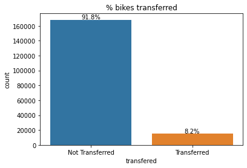

```python
sb.countplot(df_ordered['transfered'])
plt.title('% bikes transferred')
locs, labels = plt.xticks()

# loop through each pair of locations and labels
for loc, label in zip(locs, labels):

    # get the text property for the label to get the correct count
    count = trans_count[label.get_text()]
    pct_string = '{:0.1f}%'.format(100*count/df_ordered.shape[0])

    # print the annotation just below the top of the bar
    plt.text(loc, count+1000, pct_string, ha = 'center', color = 'black')
```

Now we found that company changed the location of the bike 15097 times during this month

### let's see if it was systematic or for maintaince or someone just take it without starting a trip:

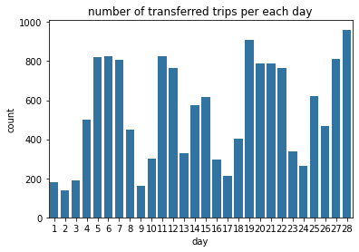

```python
df_trans= df_ordered[df_ordered['transfered'] == 'Transferred']
sb.countplot(df_trans.start_time.dt.day, color =base_color)
plt.title('number of transferred trips per each day')
plt.xlabel('day');
```

seems they are doing it every day with different counts based on the count of the bikes in each station by end of the day and may be during the day.

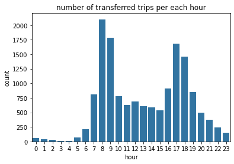

```python
sb.countplot(df_trans.start_time.dt.hour, color =base_color);
plt.title('number of transferred trips per each hour')
plt.xlabel('hour');
```

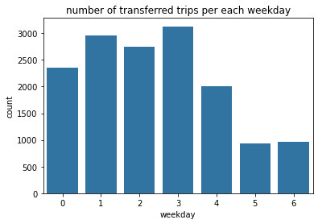

```python
sb.countplot(df_trans.start_time.dt.weekday, color =base_color)
plt.title('number of transferred trips per each weekday')
plt.xlabel('weekday');
```

from the last figure we see that they transfer the bikes mostly to fulfill the demand in the workdays. This transfer rate drop dramtically at the weekends.

```python
df_ordered.query('transfered == "True"').start_station_name.value_counts()
```

```
Series([], Name: start_station_name, dtype: int64)
```

```python
df_ordered.query('transfered == "True"').start_station_id.value_counts()
```

```
Series([], Name: start_station_id, dtype: int64)
```

### Let's get deep in some of these stations:

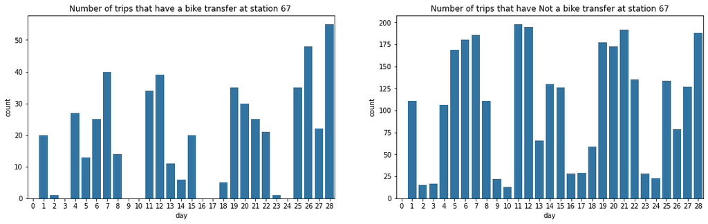

```python
# plot for station id=67
plt.figure(figsize=(18,5))
plt.subplot(1,2,1)
sb.countplot(df_ordered.query('start_station_id == "67" & transfered == "Transferred"').start_time.dt.day, color=base_color, order = np.arange(0,28+1,1))
plt.xlabel('day')
plt.title('Number of trips that have a bike transfer at station 67 ')

plt.subplot(1,2,2)
sb.countplot(df_ordered.query('start_station_id == "67" & transfered == "Not Transferred"').start_time.dt.day, color=base_color, order = np.arange(0,28+1,1))
plt.xlabel('day')
plt.title('Number of trips that have Not a bike transfer at station 67');
```

it will be so overwhelming to find when each station do not have bikes at certain times when threre is a demand for the bikes at that station. so I will check what catch my eyes and one thing that I may find interesting to check in that station is day 26. so it was a workday but have very small traffic comparing to other working days and I could see a huge number of bikes transferred to this station in that day. Let's check :

### What is the number of trips started in any certain minute in the day 26 at station number 67?

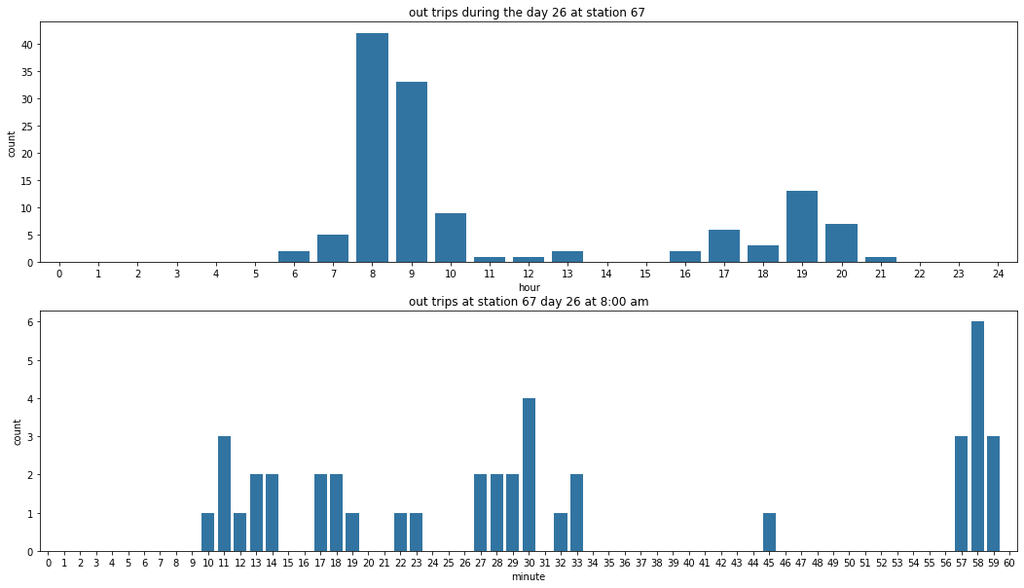

```python
#out trips from station 67 at day 26:
df_67_day26_out = df_ordered[df_ordered['start_time'].dt.day == 26].query('start_station_id == "67" ')
plt.figure(figsize=(18,10))

plt.subplot(2,1,1)
sb.countplot(df_67_day26_out.start_time.dt.hour, color=base_color, order = np.arange(0,24+1,1))
plt.title("out trips during the day 26 at station 67 ")
plt.xlabel('hour');

plt.subplot(2,1,2)
hour = 8
sb.countplot(df_67_day26_out[df_67_day26_out.start_time.dt.hour == hour].start_time.dt.minute, color=base_color, order = np.arange(0,60+1,1))
plt.title("out trips at station 67 day 26 at 8:00 am")
plt.xlabel('minute');
```

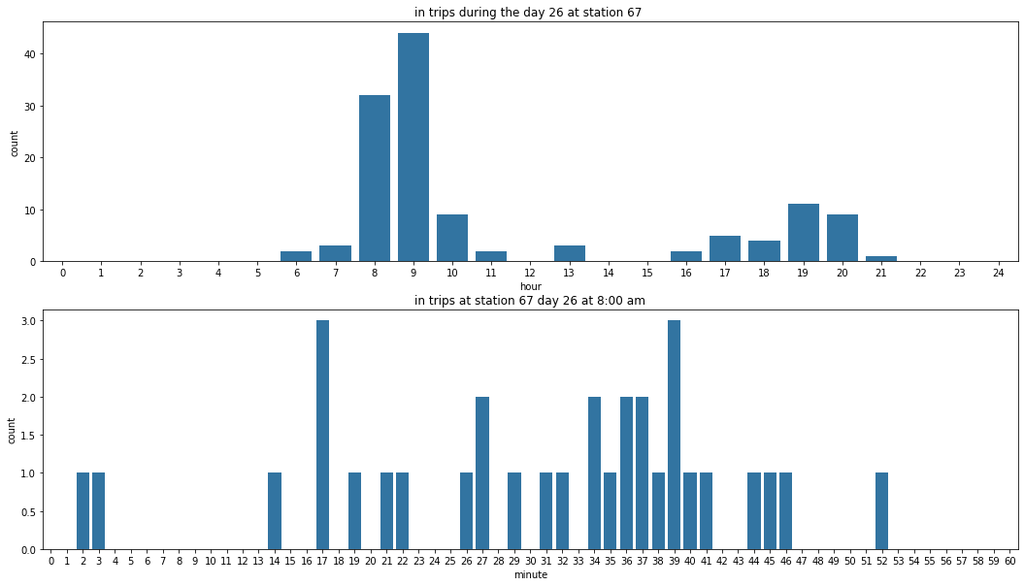

```python
#in trips from station 67 at day 26:
df_67_day26_in = df_ordered[df_ordered['end_time'].dt.day == 26].query('start_station_id == "67" ')
plt.figure(figsize=(18,10))

plt.subplot(2,1,1)
sb.countplot(df_67_day26_in.end_time.dt.hour, color=base_color, order = np.arange(0,24+1,1))
plt.title("in trips during the day 26 at station 67 ")
plt.xlabel('hour')

plt.subplot(2,1,2)
hour = 8
sb.countplot(df_67_day26_in[df_67_day26_in.end_time.dt.hour == hour].end_time.dt.minute, color=base_color, order = np.arange(0,60+1,1))
plt.title("in trips at station 67 day 26 at 8:00 am")
plt.xlabel('minute');
```

### how many bikes ended at each station by end of each day ?

Now I am going to make something very interesting (I am not sure I could do it but I will make a try).I want to calculate how many bikes in use (did not reach any station yet) by the end of each hour of each day in our data.

```python
#taking a copys :
df_start = df_ordered.copy()
df_end = df_ordered.copy()
#add prefix to bike_id "s-"
df_start['bike_id'] = 's-' + df_start['bike_id'].astype(str)
bike_id_start_station = df_start.pivot(index='start_time', columns='start_station_id', values='bike_id')
#add prefix to bike_id "f-"
df_end['bike_id'] = 'f-' + df_end['bike_id'].astype(str)
bike_id_end_station = df_end.pivot(index='end_time', columns='end_station_id', values='bike_id')
```

#### insights about each station:

```python
#no of trips started at each station and no. of unique bikes
bike_id_start_station.describe()
```

| start_station_id | 10 | 100 | 101 | 102 | 104 | 105 | 106 | 107 | 108 | 109 | ... | 9 | 90 | 91 | 92 | 93 | 95 | 96 | 97 | 98 | 99 |
| --- | --- | --- | --- | --- | --- | --- | --- | --- | --- | --- | --- | --- | --- | --- | --- | --- | --- | --- | --- | --- | --- |
| count | 793 | 684 | 630 | 570 | 1360 | 453 | 335 | 428 | 512 | 953 | ... | 905 | 1573 | 450 | 866 | 1552 | 666 | 489 | 578 | 708 | 425 |
| unique | 580 | 552 | 510 | 475 | 930 | 382 | 287 | 382 | 413 | 713 | ... | 697 | 1005 | 370 | 645 | 1018 | 529 | 421 | 482 | 574 | 358 |
| top | s-4533 | s-4959 | s-4619 | s-5265 | s-4381 | s-5222 | s-5247 | s-5065 | s-5411 | s-4812 | ... | s-4996 | s-4372 | s-5217 | s-5315 | s-4404 | s-5366 | s-4838 | s-5556 | s-5389 | s-5030 |
| freq | 5 | 4 | 6 | 4 | 7 | 3 | 4 | 3 | 4 | 5 | ... | 4 | 7 | 4 | 6 | 6 | 4 | 4 | 5 | 5 | 4 |

4 rows × 329 columns

```python
#no of trips ended at each station and no. of unique bikes
bike_id_end_station.describe()
```

| end_station_id | 10 | 100 | 101 | 102 | 104 | 105 | 106 | 107 | 108 | 109 | ... | 9 | 90 | 91 | 92 | 93 | 95 | 96 | 97 | 98 | 99 |
| --- | --- | --- | --- | --- | --- | --- | --- | --- | --- | --- | --- | --- | --- | --- | --- | --- | --- | --- | --- | --- | --- |
| count | 942 | 680 | 661 | 602 | 1208 | 404 | 311 | 347 | 526 | 970 | ... | 802 | 1540 | 409 | 854 | 1626 | 536 | 469 | 489 | 692 | 434 |
| unique | 675 | 545 | 534 | 493 | 837 | 341 | 269 | 303 | 423 | 726 | ... | 623 | 1011 | 341 | 627 | 1032 | 424 | 401 | 412 | 555 | 364 |
| top | f-5400 | f-4943 | f-4619 | f-6143 | f-4927 | f-6101 | f-5423 | f-5038 | f-5411 | f-5022 | ... | f-5050 | f-4372 | f-5540 | f-5315 | f-5030 | f-5041 | f-4838 | f-5556 | f-5389 | f-5030 |
| freq | 5 | 4 | 6 | 4 | 5 | 3 | 3 | 3 | 4 | 5 | ... | 4 | 7 | 4 | 6 | 7 | 4 | 4 | 4 | 5 | 4 |

4 rows × 329 columns

```python
df_ordered.shape, bike_id_start_station.shape, bike_id_end_station.shape
```

```
((183215, 19), (183204, 329), (183200, 329))
```

```python
#concat the 2 dataframes :
df_bike_station = pd.concat([bike_id_start_station,bike_id_end_station])
df_bike_station.index.name = 'timestamp'
```

```python
df_bike_station.shape
```

```
(366404, 329)
```

```python
#sorting the dataframe (essential in our case to know if the bike out or not from the station)
df_bike_station = df_bike_station.sort_values(by='timestamp')
```

```python
#take a sample to not over computing :
sample = df_bike_station.sample(n=5000, random_state = 1)
```

Now I am going to program a function that could take all the bike id list and count how many station in and out:

```python
bikes = ['s-6494', 's-1654', 'f-4155', 'f-6494', 's-12', 'f-145', 's-6494','f-1654']

def in_out_list(station):
    ids =[]
    in_bikes = 0
    out_bikes = 0
    ids_final = []
    for bike in station[::-1]:
        ids.append(bike)
    ids_clear = [id_ for id_ in ids if str(id_) != 'nan']
    for bike in ids_clear[::-1]:
        if bike[2:] not in ids_final:
            ids_final.append(bike[2:])
            if bike[0] == 'f':
                in_bikes += 1
            else:
                out_bikes +=1
    return ids_clear


def in_values(station):
    ids =[]
    in_bikes = 0
    out_bikes = 0
    ids_final = []
    for bike in station[::-1]:
        ids.append(bike)
    ids_clear = [id_ for id_ in ids if str(id_) != 'nan']
    for bike in ids_clear[::-1]:
        if bike[2:] not in ids_final:
            ids_final.append(bike[2:])
            if bike[0] == 'f':
                in_bikes += 1
            else:
                out_bikes +=1
    return in_bikes

def in_out_values(station):
    ids =[]
    in_bikes = 0
    out_bikes = 0
    ids_final = []
    for bike in station[::-1]:
        ids.append(bike)
    ids_clear = [id_ for id_ in ids if str(id_) != 'nan']
    for bike in ids_clear[::-1]:
        if bike[2:] not in ids_final:
            ids_final.append(bike[2:])
            if bike[0] == 'f':
                in_bikes += 1
            else:
                out_bikes +=1
    return in_bikes, out_bikes

def out_values(station):
    ids =[]
    in_bikes = 0
    out_bikes = 0
    ids_final = []
    for bike in station[::-1]:
        ids.append(bike)
    ids_clear = [id_ for id_ in ids if str(id_) != 'nan']
    for bike in ids_clear[::-1]:
        if bike[2:] not in ids_final:
            ids_final.append(bike[2:])
            if bike[0] == 'f':
                in_bikes += 1
            else:
                out_bikes +=1
    return out_bikes

in_out_values(bikes)
```

```
(2, 3)
```

Nice! we can see from the list we tested our function on it that there are 2 bikes reached and 3 bikes out

```python
station_1d = df_bike_station.resample('D').apply(in_out_values)
```

```python
station_1d
```

| timestamp | 10 | 100 | 101 | 102 | 104 | 105 | 106 | 107 | 108 | 109 | ... | 9 | 90 | 91 | 92 | 93 | 95 | 96 | 97 | 98 | 99 |
| --- | --- | --- | --- | --- | --- | --- | --- | --- | --- | --- | --- | --- | --- | --- | --- | --- | --- | --- | --- | --- | --- |
| 2019-02-01 | (27, 1) | (22, 1) | (28, 0) | (17, 5) | (65, 3) | (4, 5) | (2, 13) | (5, 15) | (12, 5) | (27, 18) | ... | (29, 3) | (68, 2) | (15, 11) | (17, 19) | (38, 20) | (10, 10) | (11, 14) | (23, 10) | (0, 0) | (15, 3) |
| 2019-02-02 | (18, 10) | (11, 1) | (5, 0) | (3, 3) | (14, 3) | (14, 0) | (7, 1) | (9, 4) | (3, 1) | (40, 10) | ... | (9, 2) | (15, 4) | (4, 3) | (15, 5) | (23, 4) | (23, 6) | (17, 2) | (15, 7) | (0, 0) | (18, 6) |
| 2019-02-03 | (26, 4) | (6, 4) | (4, 3) | (3, 1) | (8, 2) | (10, 4) | (9, 1) | (9, 10) | (8, 2) | (37, 9) | ... | (2, 6) | (11, 4) | (12, 3) | (18, 8) | (20, 6) | (21, 7) | (12, 6) | (12, 3) | (0, 0) | (15, 7) |
| 2019-02-04 | (13, 14) | (31, 3) | (24, 14) | (16, 3) | (52, 7) | (7, 6) | (7, 4) | (9, 9) | (19, 9) | (25, 15) | ... | (25, 7) | (64, 13) | (8, 7) | (19, 14) | (47, 10) | (8, 17) | (7, 4) | (12, 6) | (0, 0) | (12, 2) |
| 2019-02-05 | (36, 0) | (29, 1) | (39, 6) | (33, 5) | (61, 18) | (12, 5) | (12, 4) | (17, 19) | (32, 2) | (49, 10) | ... | (36, 13) | (79, 5) | (18, 14) | (27, 17) | (74, 5) | (18, 12) | (22, 3) | (28, 5) | (0, 0) | (18, 9) |
| 2019-02-06 | (42, 6) | (38, 1) | (36, 5) | (30, 3) | (60, 20) | (14, 3) | (17, 6) | (15, 10) | (29, 5) | (50, 15) | ... | (45, 6) | (76, 11) | (21, 11) | (35, 21) | (90, 3) | (26, 23) | (22, 7) | (26, 16) | (0, 0) | (13, 6) |
| 2019-02-07 | (35, 10) | (37, 3) | (44, 3) | (34, 6) | (65, 9) | (17, 2) | (10, 10) | (19, 6) | (25, 6) | (44, 13) | ... | (40, 15) | (96, 8) | (21, 14) | (38, 16) | (75, 9) | (23, 17) | (15, 13) | (21, 16) | (0, 0) | (24, 5) |
| 2019-02-08 | (30, 5) | (23, 1) | (33, 7) | (26, 2) | (59, 5) | (14, 8) | (8, 6) | (11, 6) | (18, 9) | (13, 12) | ... | (37, 10) | (51, 15) | (14, 10) | (26, 12) | (58, 6) | (11, 7) | (12, 3) | (9, 11) | (17, 1) | (17, 7) |
| 2019-02-09 | (15, 3) | (9, 1) | (4, 3) | (7, 2) | (14, 1) | (7, 5) | (5, 7) | (7, 1) | (4, 0) | (30, 4) | ... | (4, 1) | (13, 3) | (4, 4) | (13, 11) | (13, 1) | (11, 7) | (5, 4) | (10, 4) | (23, 6) | (8, 6) |
| 2019-02-10 | (22, 8) | (16, 1) | (3, 4) | (3, 1) | (12, 8) | (9, 6) | (8, 4) | (10, 9) | (4, 2) | (33, 12) | ... | (15, 5) | (25, 5) | (11, 6) | (16, 6) | (20, 8) | (17, 8) | (12, 3) | (13, 7) | (34, 6) | (12, 5) |
| 2019-02-11 | (44, 9) | (25, 2) | (30, 4) | (28, 11) | (68, 4) | (19, 8) | (9, 10) | (13, 10) | (21, 1) | (34, 16) | ... | (40, 20) | (77, 20) | (19, 12) | (43, 7) | (78, 18) | (19, 1) | (23, 6) | (24, 10) | (26, 18) | (17, 5) |
| 2019-02-12 | (38, 5) | (39, 0) | (34, 3) | (32, 8) | (63, 6) | (16, 6) | (14, 4) | (15, 16) | (24, 3) | (29, 14) | ... | (37, 11) | (84, 28) | (14, 14) | (32, 21) | (84, 2) | (15, 22) | (16, 13) | (20, 13) | (23, 15) | (18, 6) |
| 2019-02-13 | (12, 4) | (7, 7) | (7, 4) | (12, 2) | (22, 7) | (9, 4) | (4, 2) | (5, 3) | (16, 0) | (13, 5) | ... | (11, 12) | (28, 14) | (9, 5) | (13, 19) | (26, 15) | (9, 3) | (8, 1) | (6, 6) | (12, 7) | (8, 2) |
| 2019-02-14 | (29, 11) | (22, 4) | (26, 10) | (19, 6) | (33, 18) | (8, 15) | (11, 2) | (16, 9) | (17, 1) | (31, 8) | ... | (36, 6) | (50, 31) | (14, 13) | (31, 14) | (52, 15) | (17, 12) | (14, 12) | (10, 15) | (28, 13) | (19, 3) |
| 2019-02-15 | (29, 5) | (22, 4) | (21, 3) | (20, 6) | (44, 32) | (11, 12) | (10, 9) | (12, 12) | (17, 5) | (30, 18) | ... | (29, 14) | (56, 13) | (14, 7) | (47, 12) | (63, 7) | (11, 16) | (27, 13) | (19, 9) | (35, 15) | (5, 7) |
| 2019-02-16 | (27, 8) | (24, 0) | (4, 1) | (3, 2) | (21, 7) | (20, 9) | (5, 6) | (14, 5) | (3, 9) | (24, 6) | ... | (5, 4) | (14, 2) | (5, 8) | (11, 14) | (24, 7) | (14, 7) | (6, 12) | (16, 13) | (41, 6) | (16, 4) |
| 2019-02-17 | (31, 8) | (23, 1) | (1, 3) | (7, 2) | (9, 7) | (16, 2) | (11, 0) | (9, 4) | (10, 2) | (37, 8) | ... | (17, 5) | (14, 4) | (13, 3) | (18, 8) | (17, 7) | (26, 4) | (16, 2) | (10, 11) | (30, 21) | (9, 6) |
| 2019-02-18 | (17, 8) | (22, 8) | (16, 3) | (19, 3) | (28, 5) | (15, 6) | (6, 7) | (8, 9) | (12, 4) | (33, 3) | ... | (17, 8) | (29, 9) | (6, 11) | (28, 10) | (52, 6) | (27, 10) | (19, 6) | (18, 7) | (36, 10) | (18, 7) |
| 2019-02-19 | (35, 10) | (29, 3) | (48, 2) | (24, 16) | (57, 18) | (23, 18) | (12, 4) | (16, 13) | (26, 5) | (31, 12) | ... | (31, 13) | (70, 23) | (23, 11) | (42, 14) | (77, 12) | (22, 21) | (26, 8) | (21, 13) | (39, 16) | (18, 5) |
| 2019-02-20 | (39, 10) | (23, 9) | (31, 2) | (34, 2) | (58, 18) | (18, 16) | (22, 9) | (19, 22) | (30, 5) | (37, 19) | ... | (44, 14) | (94, 7) | (23, 16) | (43, 17) | (68, 15) | (19, 17) | (26, 16) | (22, 8) | (34, 14) | (19, 11) |
| 2019-02-21 | (48, 8) | (40, 1) | (41, 2) | (41, 12) | (54, 16) | (15, 3) | (16, 16) | (12, 10) | (26, 6) | (25, 17) | ... | (39, 11) | (75, 16) | (16, 18) | (43, 22) | (84, 4) | (28, 22) | (17, 14) | (15, 16) | (40, 16) | (23, 6) |
| 2019-02-22 | (36, 5) | (24, 8) | (34, 4) | (24, 5) | (55, 22) | (29, 7) | (26, 12) | (7, 15) | (20, 7) | (43, 13) | ... | (52, 3) | (71, 16) | (18, 14) | (32, 15) | (84, 7) | (29, 10) | (27, 7) | (18, 9) | (50, 15) | (16, 5) |
| 2019-02-23 | (53, 20) | (18, 4) | (7, 1) | (11, 5) | (26, 4) | (26, 5) | (9, 9) | (17, 9) | (10, 2) | (51, 16) | ... | (19, 6) | (24, 3) | (13, 7) | (28, 9) | (35, 8) | (26, 9) | (18, 12) | (21, 5) | (37, 14) | (8, 2) |
| 2019-02-24 | (37, 16) | (12, 6) | (1, 5) | (11, 1) | (14, 8) | (16, 8) | (10, 3) | (12, 6) | (10, 3) | (49, 10) | ... | (7, 5) | (16, 5) | (9, 7) | (18, 10) | (39, 4) | (24, 8) | (20, 8) | (13, 16) | (41, 8) | (14, 6) |
| 2019-02-25 | (28, 7) | (26, 4) | (27, 6) | (25, 8) | (44, 10) | (15, 6) | (8, 14) | (14, 9) | (24, 3) | (24, 11) | ... | (25, 5) | (51, 6) | (18, 10) | (22, 17) | (52, 23) | (8, 20) | (8, 15) | (20, 17) | (28, 13) | (9, 5) |
| 2019-02-26 | (20, 7) | (16, 6) | (19, 4) | (21, 0) | (41, 7) | (5, 5) | (6, 8) | (3, 7) | (16, 6) | (12, 13) | ... | (26, 5) | (58, 2) | (9, 10) | (13, 21) | (70, 9) | (11, 6) | (9, 7) | (14, 9) | (17, 5) | (10, 2) |
| 2019-02-27 | (38, 7) | (35, 1) | (28, 2) | (38, 2) | (45, 14) | (12, 9) | (18, 8) | (12, 7) | (21, 5) | (26, 17) | ... | (43, 0) | (71, 30) | (16, 8) | (41, 15) | (60, 18) | (20, 7) | (17, 17) | (15, 12) | (28, 10) | (15, 9) |
| 2019-02-28 | (39, 7) | (33, 4) | (37, 2) | (38, 6) | (64, 23) | (13, 13) | (15, 17) | (16, 11) | (29, 6) | (43, 21) | ... | (39, 0) | (75, 22) | (18, 14) | (51, 19) | (106, 3) | (26, 19) | (17, 17) | (18, 17) | (44, 22) | (21, 5) |
| 2019-03-01 | (0, 0) | (0, 0) | (0, 0) | (0, 0) | (0, 0) | (0, 0) | (0, 0) | (0, 0) | (0, 0) | (0, 0) | ... | (0, 0) | (0, 0) | (0, 0) | (0, 0) | (0, 0) | (0, 0) | (0, 0) | (0, 0) | (0, 0) | (0, 0) |

29 rows × 329 columns

Finally I did it! after long times of trial and errors I made what I want. In the above table we could know how many bikes parked in each station by end of the day and the number of bikes that left off the station and did not reach any station yet.

```python
#getting the difference between df_ordered and test datasets no of rows:
bool_start_stat = ~bike_id_start_station.isna()
bool_end_stat = ~bike_id_end_station.isna()
```

```python
trips_day = bool_start_stat.reset_index().resample('D', on='start_time').sum()
```

```python
#focus on stations with the most transferred bikes
top_3_stations = trips_day[['67', '243', '30']]
top_3_stations
```

[output not shown]

| start_station_id start_time | 67 | 243 | 30 |
| --- | --- | --- | --- |
| 2019-02-01 | 131 | 48 | 103 |
| 2019-02-02 | 16 | 27 | 17 |
| 2019-02-03 | 17 | 36 | 5 |
| 2019-02-04 | 133 | 70 | 91 |
| 2019-02-05 | 182 | 91 | 167 |
| 2019-02-06 | 205 | 112 | 141 |
| 2019-02-07 | 226 | 89 | 150 |
| 2019-02-08 | 125 | 44 | 125 |
| 2019-02-09 | 22 | 19 | 7 |
| 2019-02-10 | 13 | 38 | 17 |
| 2019-02-11 | 232 | 59 | 138 |
| 2019-02-12 | 234 | 80 | 147 |
| 2019-02-13 | 77 | 59 | 50 |
| 2019-02-14 | 136 | 79 | 114 |
| 2019-02-15 | 146 | 60 | 134 |
| 2019-02-16 | 28 | 51 | 15 |
| 2019-02-17 | 29 | 23 | 13 |
| 2019-02-18 | 64 | 32 | 38 |
| 2019-02-19 | 212 | 100 | 161 |
| 2019-02-20 | 203 | 127 | 176 |
| 2019-02-21 | 217 | 90 | 159 |
| 2019-02-22 | 156 | 74 | 172 |
| 2019-02-23 | 29 | 39 | 13 |
| 2019-02-24 | 23 | 45 | 17 |
| 2019-02-25 | 169 | 70 | 165 |
| 2019-02-26 | 127 | 59 | 105 |
| 2019-02-27 | 149 | 65 | 149 |
| 2019-02-28 | 243 | 84 | 114 |

```python
#save this data for explantory part
top_3_stations.to_csv('top_3_stations.csv')
```

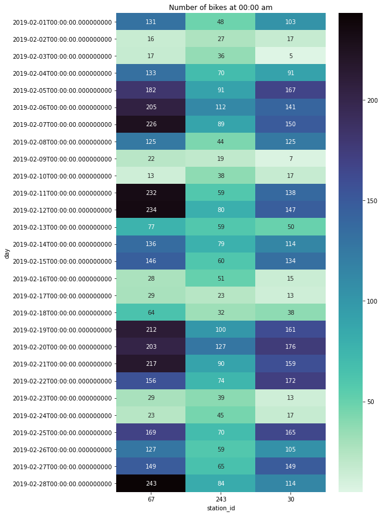

```python
plt.figure(figsize = (8,15))
sb.heatmap(top_3_stations, annot=True, fmt="d", cmap="mako_r")
plt.title('Number of bikes at 00:00 am')
plt.ylabel('day')
plt.xlabel('station_id');
```

Now, We could do it at different intervels based on the resample function inside argument.

### how many bikes are used by end of each hour of each day ?

I Will do it every 1 hour now so we will (24hr *28day + some number) rows* based on the number of trips reached the final station in 01-03-2019*

```python
station_1hr = df_bike_station.resample('H').apply(in_out_values)
```

```python
station_1hr.head(24)
```

| timestamp | 10 | 100 | 101 | 102 | 104 | 105 | 106 | 107 | 108 | 109 | ... | 9 | 90 | 91 | 92 | 93 | 95 | 96 | 97 | 98 | 99 |
| --- | --- | --- | --- | --- | --- | --- | --- | --- | --- | --- | --- | --- | --- | --- | --- | --- | --- | --- | --- | --- | --- |
| 2019-02-01 00:00:00 | (0, 0) | (0, 0) | (0, 0) | (0, 0) | (0, 0) | (0, 0) | (0, 0) | (0, 0) | (0, 0) | (0, 0) | ... | (0, 0) | (0, 0) | (0, 0) | (0, 0) | (1, 0) | (0, 1) | (1, 0) | (0, 0) | (0, 0) | (0, 0) |
| 2019-02-01 01:00:00 | (1, 0) | (0, 0) | (0, 0) | (0, 0) | (0, 0) | (0, 0) | (0, 0) | (0, 0) | (0, 0) | (1, 0) | ... | (0, 0) | (0, 0) | (2, 0) | (0, 0) | (0, 0) | (0, 0) | (0, 0) | (0, 0) | (0, 0) | (0, 0) |
| 2019-02-01 02:00:00 | (0, 0) | (0, 0) | (0, 0) | (0, 0) | (0, 0) | (0, 1) | (0, 0) | (0, 0) | (0, 0) | (0, 0) | ... | (0, 0) | (0, 0) | (0, 0) | (0, 0) | (0, 0) | (0, 0) | (0, 0) | (0, 0) | (0, 0) | (0, 0) |
| 2019-02-01 03:00:00 | (0, 0) | (0, 0) | (0, 0) | (0, 0) | (0, 0) | (0, 0) | (0, 0) | (0, 0) | (0, 0) | (0, 0) | ... | (0, 0) | (0, 0) | (0, 0) | (0, 0) | (0, 0) | (0, 0) | (0, 0) | (0, 0) | (0, 0) | (0, 0) |
| 2019-02-01 04:00:00 | (0, 0) | (0, 0) | (0, 0) | (0, 0) | (0, 0) | (0, 0) | (0, 2) | (0, 0) | (0, 0) | (0, 0) | ... | (0, 0) | (0, 0) | (0, 0) | (0, 0) | (0, 0) | (0, 0) | (0, 0) | (0, 0) | (0, 0) | (0, 0) |
| 2019-02-01 05:00:00 | (1, 0) | (0, 0) | (0, 0) | (1, 0) | (0, 1) | (0, 0) | (0, 1) | (0, 1) | (0, 0) | (0, 0) | ... | (0, 0) | (0, 1) | (0, 1) | (0, 1) | (1, 0) | (0, 0) | (0, 0) | (0, 1) | (0, 0) | (0, 0) |
| 2019-02-01 06:00:00 | (0, 0) | (1, 0) | (0, 0) | (1, 1) | (3, 0) | (0, 1) | (0, 1) | (0, 0) | (0, 0) | (0, 0) | ... | (0, 0) | (4, 0) | (0, 0) | (1, 0) | (0, 0) | (0, 0) | (0, 0) | (0, 0) | (0, 0) | (0, 0) |
| 2019-02-01 07:00:00 | (2, 1) | (1, 0) | (1, 0) | (1, 1) | (12, 1) | (0, 2) | (0, 3) | (0, 2) | (0, 1) | (0, 5) | ... | (0, 0) | (5, 2) | (1, 3) | (0, 5) | (2, 0) | (0, 0) | (0, 2) | (1, 4) | (0, 0) | (0, 2) |
| 2019-02-01 08:00:00 | (2, 1) | (4, 0) | (4, 0) | (5, 1) | (13, 9) | (0, 1) | (0, 2) | (1, 10) | (2, 1) | (2, 8) | ... | (10, 2) | (22, 0) | (1, 4) | (0, 11) | (8, 2) | (1, 0) | (0, 8) | (1, 5) | (0, 0) | (4, 0) |
| 2019-02-01 09:00:00 | (6, 0) | (4, 3) | (10, 1) | (4, 1) | (16, 7) | (0, 0) | (0, 4) | (0, 2) | (2, 3) | (1, 4) | ... | (13, 2) | (15, 4) | (1, 5) | (5, 0) | (2, 4) | (0, 0) | (0, 4) | (3, 1) | (0, 0) | (0, 2) |
| 2019-02-01 10:00:00 | (4, 1) | (4, 2) | (2, 1) | (0, 0) | (3, 5) | (1, 0) | (0, 0) | (0, 0) | (1, 0) | (1, 1) | ... | (1, 0) | (2, 1) | (0, 1) | (1, 2) | (4, 4) | (0, 5) | (1, 1) | (0, 1) | (0, 0) | (1, 0) |
| 2019-02-01 11:00:00 | (3, 1) | (2, 2) | (2, 3) | (0, 1) | (4, 1) | (0, 0) | (0, 0) | (0, 0) | (2, 0) | (0, 1) | ... | (1, 2) | (3, 7) | (2, 0) | (0, 1) | (3, 6) | (0, 2) | (0, 0) | (4, 0) | (0, 0) | (0, 1) |
| 2019-02-01 12:00:00 | (0, 2) | (1, 0) | (3, 4) | (1, 0) | (3, 3) | (1, 0) | (1, 0) | (0, 0) | (1, 1) | (7, 0) | ... | (1, 2) | (4, 1) | (1, 0) | (1, 0) | (2, 3) | (0, 0) | (2, 0) | (0, 1) | (0, 0) | (3, 0) |
| 2019-02-01 13:00:00 | (0, 5) | (2, 1) | (7, 1) | (2, 1) | (1, 2) | (0, 0) | (1, 1) | (2, 0) | (0, 1) | (0, 1) | ... | (0, 0) | (1, 0) | (1, 0) | (0, 3) | (2, 3) | (1, 1) | (1, 1) | (2, 1) | (0, 0) | (2, 0) |
| 2019-02-01 14:00:00 | (2, 2) | (0, 0) | (1, 1) | (1, 0) | (1, 1) | (0, 0) | (0, 0) | (0, 0) | (0, 1) | (0, 3) | ... | (0, 0) | (0, 8) | (0, 0) | (1, 0) | (2, 1) | (0, 0) | (0, 1) | (3, 0) | (0, 0) | (1, 0) |
| 2019-02-01 15:00:00 | (1, 0) | (1, 0) | (1, 0) | (0, 3) | (2, 4) | (0, 0) | (0, 1) | (0, 0) | (0, 0) | (1, 0) | ... | (0, 4) | (5, 0) | (1, 1) | (2, 0) | (3, 7) | (1, 0) | (1, 0) | (0, 3) | (0, 0) | (0, 2) |
| 2019-02-01 16:00:00 | (0, 2) | (0, 2) | (1, 3) | (2, 2) | (3, 7) | (0, 0) | (0, 0) | (0, 0) | (1, 0) | (4, 1) | ... | (0, 5) | (0, 4) | (1, 0) | (1, 1) | (1, 3) | (1, 0) | (1, 0) | (3, 2) | (0, 0) | (3, 0) |
| 2019-02-01 17:00:00 | (2, 1) | (0, 2) | (1, 3) | (0, 2) | (0, 3) | (1, 0) | (0, 0) | (0, 0) | (2, 1) | (3, 0) | ... | (2, 5) | (4, 2) | (0, 0) | (0, 1) | (5, 7) | (2, 2) | (4, 0) | (3, 0) | (0, 0) | (1, 0) |
| 2019-02-01 18:00:00 | (2, 0) | (1, 1) | (0, 3) | (1, 0) | (0, 3) | (1, 0) | (0, 0) | (1, 0) | (0, 1) | (2, 0) | ... | (1, 2) | (2, 1) | (2, 0) | (1, 0) | (1, 0) | (2, 0) | (0, 1) | (1, 0) | (0, 0) | (1, 1) |
| 2019-02-01 19:00:00 | (1, 1) | (0, 0) | (0, 0) | (0, 1) | (0, 1) | (0, 1) | (0, 0) | (0, 0) | (0, 0) | (4, 1) | ... | (0, 0) | (1, 2) | (1, 0) | (1, 0) | (1, 0) | (1, 1) | (0, 0) | (2, 1) | (0, 0) | (0, 1) |
| 2019-02-01 20:00:00 | (0, 0) | (1, 0) | (0, 0) | (0, 0) | (3, 0) | (0, 0) | (0, 0) | (1, 0) | (0, 0) | (1, 5) | ... | (0, 0) | (0, 0) | (1, 0) | (0, 0) | (0, 0) | (0, 0) | (0, 1) | (0, 0) | (0, 0) | (0, 0) |
| 2019-02-01 21:00:00 | (0, 0) | (0, 1) | (0, 0) | (0, 0) | (1, 0) | (0, 0) | (0, 0) | (0, 0) | (1, 0) | (0, 1) | ... | (0, 0) | (0, 0) | (0, 2) | (1, 0) | (0, 0) | (0, 0) | (0, 1) | (1, 0) | (0, 0) | (0, 0) |
| 2019-02-01 22:00:00 | (2, 0) | (0, 0) | (0, 0) | (0, 0) | (0, 1) | (0, 1) | (0, 0) | (1, 0) | (0, 1) | (1, 1) | ... | (0, 0) | (0, 0) | (0, 1) | (2, 1) | (1, 0) | (1, 0) | (0, 0) | (0, 0) | (0, 0) | (0, 0) |
| 2019-02-01 23:00:00 | (1, 0) | (1, 0) | (0, 0) | (0, 0) | (0, 1) | (0, 0) | (0, 0) | (0, 0) | (0, 0) | (0, 0) | ... | (1, 0) | (1, 0) | (0, 0) | (0, 0) | (0, 0) | (0, 0) | (0, 0) | (0, 2) | (0, 0) | (0, 0) |

24 rows × 329 columns

Those are the trips in and out for the first day of the month by the end of each hour.

```python
station_1hr.tail(12)
```

| timestamp | 10 | 100 | 101 | 102 | 104 | 105 | 106 | 107 | 108 | 109 | ... | 9 | 90 | 91 | 92 | 93 | 95 | 96 | 97 | 98 | 99 |
| --- | --- | --- | --- | --- | --- | --- | --- | --- | --- | --- | --- | --- | --- | --- | --- | --- | --- | --- | --- | --- | --- |
| 2019-02-28 21:00:00 | (2, 2) | (0, 0) | (1, 1) | (0, 2) | (0, 3) | (0, 1) | (2, 0) | (2, 0) | (1, 1) | (1, 2) | ... | (1, 1) | (5, 0) | (0, 1) | (3, 0) | (2, 1) | (0, 1) | (1, 2) | (2, 0) | (2, 3) | (0, 1) |
| 2019-02-28 22:00:00 | (0, 1) | (0, 0) | (0, 0) | (0, 0) | (1, 0) | (0, 0) | (1, 0) | (0, 3) | (0, 0) | (2, 2) | ... | (0, 0) | (0, 1) | (0, 0) | (1, 1) | (0, 1) | (3, 3) | (1, 0) | (0, 2) | (0, 1) | (0, 0) |
| 2019-02-28 23:00:00 | (1, 2) | (0, 0) | (0, 0) | (0, 0) | (0, 1) | (0, 0) | (0, 1) | (1, 0) | (0, 0) | (1, 1) | ... | (1, 0) | (0, 0) | (0, 0) | (0, 0) | (2, 0) | (0, 0) | (1, 0) | (0, 0) | (1, 1) | (0, 0) |
| 2019-03-01 00:00:00 | (0, 0) | (0, 0) | (0, 0) | (0, 0) | (0, 0) | (0, 0) | (0, 0) | (0, 0) | (0, 0) | (0, 0) | ... | (0, 0) | (0, 0) | (0, 0) | (0, 0) | (0, 0) | (0, 0) | (0, 0) | (0, 0) | (0, 0) | (0, 0) |
| 2019-03-01 01:00:00 | (0, 0) | (0, 0) | (0, 0) | (0, 0) | (0, 0) | (0, 0) | (0, 0) | (0, 0) | (0, 0) | (0, 0) | ... | (0, 0) | (0, 0) | (0, 0) | (0, 0) | (0, 0) | (0, 0) | (0, 0) | (0, 0) | (0, 0) | (0, 0) |
| 2019-03-01 02:00:00 | (0, 0) | (0, 0) | (0, 0) | (0, 0) | (0, 0) | (0, 0) | (0, 0) | (0, 0) | (0, 0) | (0, 0) | ... | (0, 0) | (0, 0) | (0, 0) | (0, 0) | (0, 0) | (0, 0) | (0, 0) | (0, 0) | (0, 0) | (0, 0) |
| 2019-03-01 03:00:00 | (0, 0) | (0, 0) | (0, 0) | (0, 0) | (0, 0) | (0, 0) | (0, 0) | (0, 0) | (0, 0) | (0, 0) | ... | (0, 0) | (0, 0) | (0, 0) | (0, 0) | (0, 0) | (0, 0) | (0, 0) | (0, 0) | (0, 0) | (0, 0) |
| 2019-03-01 04:00:00 | (0, 0) | (0, 0) | (0, 0) | (0, 0) | (0, 0) | (0, 0) | (0, 0) | (0, 0) | (0, 0) | (0, 0) | ... | (0, 0) | (0, 0) | (0, 0) | (0, 0) | (0, 0) | (0, 0) | (0, 0) | (0, 0) | (0, 0) | (0, 0) |
| 2019-03-01 05:00:00 | (0, 0) | (0, 0) | (0, 0) | (0, 0) | (0, 0) | (0, 0) | (0, 0) | (0, 0) | (0, 0) | (0, 0) | ... | (0, 0) | (0, 0) | (0, 0) | (0, 0) | (0, 0) | (0, 0) | (0, 0) | (0, 0) | (0, 0) | (0, 0) |
| 2019-03-01 06:00:00 | (0, 0) | (0, 0) | (0, 0) | (0, 0) | (0, 0) | (0, 0) | (0, 0) | (0, 0) | (0, 0) | (0, 0) | ... | (0, 0) | (0, 0) | (0, 0) | (0, 0) | (0, 0) | (0, 0) | (0, 0) | (0, 0) | (0, 0) | (0, 0) |
| 2019-03-01 07:00:00 | (0, 0) | (0, 0) | (0, 0) | (0, 0) | (0, 0) | (0, 0) | (0, 0) | (0, 0) | (0, 0) | (0, 0) | ... | (0, 0) | (0, 0) | (0, 0) | (0, 0) | (0, 0) | (0, 0) | (0, 0) | (0, 0) | (0, 0) | (0, 0) |
| 2019-03-01 08:00:00 | (0, 0) | (0, 0) | (0, 0) | (0, 0) | (0, 0) | (0, 0) | (0, 0) | (0, 0) | (0, 0) | (0, 0) | ... | (0, 0) | (0, 0) | (0, 0) | (0, 0) | (0, 0) | (0, 0) | (0, 0) | (0, 0) | (0, 0) | (0, 0) |

12 rows × 329 columns

The last trip reached between 8:00am and 9:00am so we will have 9 aditional rows. I will extract the out bikes number from each value and sum up for each row to get the number of bikes that in use in that time. Is not beautiful?

These are the number of trips ended in each station by the end of the day. There is two things must be considered, first we must exclude the bikes that started a new trip after the last end time in that day (a bike may start in a day and end in the following day) and the second thing we must consider is the same bike may have the same end station multiple times during the day so we must count the unique bike ids. we should also include another column for the count of bikes outside the stations.

**let's know how much bikes are used by end of each hour**

```python
station_1hr_out = df_bike_station.resample('H').apply(out_values)
```

```python
station_1hr_out.head(24).sum()
```

```
10     17
100    14
101    20
102    14
104    50
       ..
95     12
96     20
97     22
98      0
99      9
Length: 329, dtype: int64
```

```python
bike_used_1hr = station_1hr_out.sum(axis=1)
```

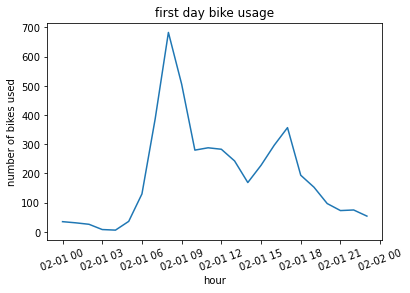

```python
#ploting the first day of data
bike_used_1hr_day_1 = bike_used_1hr.head(24)


bike_used_1hr_day_1 = pd.DataFrame({'timestamp':bike_used_1hr_day_1.index, 'count':bike_used_1hr_day_1.values})
plt.errorbar(data =bike_used_1hr_day_1 ,x='timestamp', y= 'count')
plt.xticks(rotation=20)
plt.title('first day bike usage')
plt.ylabel('number of bikes used')
plt.xlabel('hour');
```

```python
bike_used_1hr = pd.DataFrame({'timestamp':bike_used_1hr.index, 'count':bike_used_1hr.values})
```

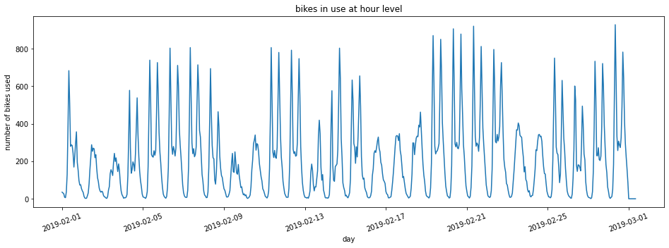

```python
#ploting for the whole data:
plt.figure(figsize=(16,5))
plt.errorbar(data =bike_used_1hr ,x='timestamp', y= 'count')
plt.xticks(rotation=20)
plt.title('bikes in use at hour level')
plt.ylabel('number of bikes used')
plt.xlabel('day');
```

#### getting the no. of trips with the same exact timestamp:

```python
#get the rows with multiple True values(has the same timpstamp):
bool_start_stat[bool_start_stat.sum(axis=1) > 1]
```

| start_station_id start_time | 10 | 100 | 101 | 102 | 104 | 105 | 106 | 107 | 108 | 109 | ... | 9 | 90 | 91 | 92 | 93 | 95 | 96 | 97 | 98 | 99 |
| --- | --- | --- | --- | --- | --- | --- | --- | --- | --- | --- | --- | --- | --- | --- | --- | --- | --- | --- | --- | --- | --- |
| 2019-02-01 13:40:09.492 | False | False | False | False | False | False | False | False | False | False | ... | False | False | False | False | False | False | False | False | False | False |
| 2019-02-01 18:24:34.874 | False | False | False | False | False | False | False | False | False | False | ... | False | False | False | False | False | False | False | False | False | False |
| 2019-02-06 21:35:57.574 | False | False | False | False | False | False | False | False | False | False | ... | False | True | False | False | False | False | False | False | False | False |
| 2019-02-07 09:06:07.056 | False | False | False | False | False | False | False | False | False | False | ... | False | False | False | False | False | False | False | False | False | False |
| 2019-02-07 17:56:08.897 | False | False | False | False | False | False | False | False | False | False | ... | False | False | False | False | False | False | False | False | False | False |
| 2019-02-11 17:05:07.840 | False | False | False | False | False | False | False | False | False | False | ... | False | False | False | False | False | False | False | False | False | False |
| 2019-02-15 07:47:00.197 | False | False | False | False | False | False | False | False | False | False | ... | False | False | False | False | False | False | False | False | False | False |
| 2019-02-15 08:43:18.422 | False | False | False | False | False | False | False | False | False | False | ... | False | False | False | False | False | False | False | False | False | False |
| 2019-02-19 17:52:44.175 | False | False | False | False | False | False | False | False | False | False | ... | False | False | False | False | False | False | False | False | False | False |
| 2019-02-22 20:11:42.256 | False | False | False | False | False | False | False | False | False | False | ... | False | False | False | True | False | False | False | False | False | False |
| 2019-02-25 08:52:07.582 | False | False | False | False | False | False | False | False | False | False | ... | False | False | False | False | False | False | False | False | False | False |

11 rows × 329 columns

```python
bool_end_stat[bool_end_stat.sum(axis=1) > 1]
```

| end_station_id end_time | 10 | 100 | 101 | 102 | 104 | 105 | 106 | 107 | 108 | 109 | ... | 9 | 90 | 91 | 92 | 93 | 95 | 96 | 97 | 98 | 99 |
| --- | --- | --- | --- | --- | --- | --- | --- | --- | --- | --- | --- | --- | --- | --- | --- | --- | --- | --- | --- | --- | --- |
| 2019-02-05 17:48:45.824 | False | False | False | False | False | False | False | False | False | False | ... | False | False | False | False | False | False | False | False | False | False |
| 2019-02-06 18:22:42.379 | False | False | False | False | False | False | False | False | False | False | ... | False | False | False | False | False | False | False | False | False | False |
| 2019-02-11 07:47:02.556 | False | False | False | False | False | False | False | False | False | False | ... | False | False | False | False | False | False | False | False | False | False |
| 2019-02-11 08:03:22.602 | False | False | False | False | False | False | False | False | False | False | ... | False | False | False | False | False | False | False | False | False | False |
| 2019-02-11 18:53:55.082 | False | False | False | False | False | False | False | False | False | False | ... | False | False | False | False | False | False | False | False | False | False |
| 2019-02-12 09:07:04.475 | False | False | False | False | False | False | False | False | False | False | ... | False | False | False | False | False | False | False | False | False | False |
| 2019-02-12 17:52:28.028 | False | False | False | False | False | False | False | False | False | False | ... | False | False | False | False | False | False | False | False | False | False |
| 2019-02-14 08:20:06.230 | False | False | False | False | False | False | False | False | False | False | ... | False | False | False | False | False | False | False | False | False | False |
| 2019-02-14 17:26:25.473 | False | False | False | False | False | False | False | False | False | False | ... | False | False | False | False | False | False | False | False | False | False |
| 2019-02-14 18:14:03.928 | False | False | False | False | False | False | False | False | False | False | ... | False | False | False | False | False | False | False | False | False | False |
| 2019-02-20 09:40:38.450 | False | False | False | False | False | False | False | False | False | False | ... | False | False | False | False | False | False | False | False | False | False |
| 2019-02-21 22:16:04.478 | False | False | False | False | False | False | False | False | False | False | ... | False | False | False | False | True | False | False | False | False | False |
| 2019-02-22 07:55:50.786 | False | False | False | False | False | False | False | False | False | False | ... | False | False | False | False | True | False | False | False | False | False |
| 2019-02-23 12:07:02.570 | True | False | False | False | False | False | False | False | False | False | ... | False | False | False | False | False | False | False | False | False | False |
| 2019-02-28 17:40:37.328 | False | False | False | False | False | False | False | False | False | False | ... | False | False | False | False | False | False | False | False | False | False |

15 rows × 329 columns

There are 11 rows with the exact same start_time timestamp and 15 rows with the same end_time timestamp , Interesting!

We can extend our exploration by programing function to change day, time, hour or even minutes. that would be effective in discovering new insights about our data.

As you could see, the exploration is an endless process, every time you add a variable you discover many things to be investigated. so to end this enjoyable and frustrating at the same time(because of the project deadline), I will make some vizs to show what I have explored.